# What do people die from?

An exploratory data analysis

Mathieu Beaudoin

November 24, 2020

# Foreword

In this analysis, we will explore a [dataset](https://ourworldindata.org/causes-of-death#what-do-people-die-from) from OurWorldInData.org, regarding causes of death by country, from 1990 to 2016. We hypothesize that certain causes will tend to cluster together:

- developed countries have successfully reduced their mortality rates from causes that still afflict poorer countries, but in turn their citizens tend to die more of age-related illness
- climate differences probably have an impact - while, in the cold, dark Canadian winter we may be dreaming of tropical climes, the cold also protects us from all sorts of critters and diseases that might otherwise kill us!

# Setup

```r
data_path <- paste0("https://raw.githubusercontent.com/MathieuBeaudoin/Mortality/main/Data/")
dataset_name <- "annual-number-of-deaths-by-cause.csv"
deaths <- read.csv(paste0(data_path, dataset_name), header=T)
set.seed(42)

packages <- c("corrplot", "FactoMineR", "factoextra", "ggplot2", "dplyr",
              "mapproj", "gridExtra", "superheat", "RColorBrewer", "VIM")
for(pkg in packages) library(pkg, character.only=T)
```

# Data Cleaning

```r
colnames(deaths)
```

```
##  [1] "Entity"
##  [2] "Code"
##  [3] "Year"
##  [4] "Number.of.executions..Amnesty.International."
##  [5] "Deaths...Road.injuries...Sex..Both...Age..All.Ages..Number."
##  [6] "Deaths...Cirrhosis.and.other.chronic.liver.diseases...Sex..Both...Age..All.Ages..Number."
##  [7] "Deaths...Digestive.diseases...Sex..Both...Age..All.Ages..Number."
##  [8] "Deaths...Tuberculosis...Sex..Both...Age..All.Ages..Number."
##  [9] "Deaths...HIV.AIDS...Sex..Both...Age..All.Ages..Number."
## [10] "Deaths...Diarrheal.diseases...Sex..Both...Age..All.Ages..Number."
## [11] "Deaths...Intestinal.infectious.diseases...Sex..Both...Age..All.Ages..Number."
## [12] "Deaths...Lower.respiratory.infections...Sex..Both...Age..All.Ages..Number."
## [13] "Deaths...Meningitis...Sex..Both...Age..All.Ages..Number."
## [14] "Deaths...Drowning...Sex..Both...Age..All.Ages..Number."
## [15] "Deaths...Alzheimer.disease.and.other.dementias...Sex..Both...Age..All.Ages..Number."
```

[output cut: 22 more lines]

```r
causes <- c("Execution", "RoadInjuries", "ChronicLiverDis", "DigestiveDis",
            "Tuberculosis", "HIV_AIDS", "DiarrhealDisease", "IntestinalInfectiousDis",
            "LowerRespiratoryInfection", "Meningitis", "Drowning", "AlzheimerDis",
            "ParkinsonDis", "AlcoholDisorder", "DrugDisorder", "Malaria",
            "MaternalDisorder", "NeonatalDisorder", "NutritionalDeficiency",
            "Diabetes", "ChronicKidneyDis", "ChronicRespiratoryDis", "Conflict",
            "Hepatitis", "Neoplasm", "FireHeatHotSubstances", "Poisoning",
            "ExposureToForcesOfNature", "EnvironmentalHeatColdExposure",
            "ProteinEnergyMalnutrition", "CardiovascularDis", "SelfHarm",
            "InterpersonalViolence", "Terrorism")
colnames(deaths)[-(1:3)] <- causes
summary(deaths)
```

```
##                   Entity          Code           Year        Execution
##  Afghanistan         :  28          :1141   Min.   :1990          :6419
##  Albania             :  28   AFG    :  28   1st Qu.:1996   0      :  43
##  Algeria             :  28   AGO    :  28   Median :2003   1      :  33
##  American Samoa      :  28   ALB    :  28   Mean   :2003   2      :  17
##  Andean Latin America:  28   AND    :  28   3rd Qu.:2010   3      :  13
##  Andorra             :  28   ARE    :  28   Max.   :2017   4      :  13
##  (Other)             :6518   (Other):5405                  (Other): 148
##   RoadInjuries       ChronicLiverDis      DigestiveDis
##  Min.   :      2.4   Min.   :      4.3   Min.   :      7.7
##  1st Qu.:    335.6   1st Qu.:    237.9   1st Qu.:    513.8
##  Median :   1854.4   Median :   1501.7   Median :   2968.2
##  Mean   :  25559.7   Mean   :  22704.3   Mean   :  41290.4
##  3rd Qu.:   7697.0   3rd Qu.:   6751.8   3rd Qu.:  13259.6
##  Max.   :1299938.5   Max.   :1322867.9   Max.   :2377684.9
##  NA's   :218         NA's   :218         NA's   :218
##   Tuberculosis          HIV_AIDS         DiarrhealDisease
##  Min.   :      0.1   Min.   :      0.0   Min.   :      0.2
##  1st Qu.:     59.2   1st Qu.:     25.8   1st Qu.:     39.5
##  Median :    745.9   Median :    272.0   Median :    633.9
##  Mean   :  28791.1   Mean   :  28082.3   Mean   :  39182.7
##  3rd Qu.:   5795.2   3rd Qu.:   4897.5   3rd Qu.:   7544.9
##  Max.   :1624707.6   Max.   :1953141.3   Max.   :2578291.7
##  NA's   :218         NA's   :218         NA's   :218
##  IntestinalInfectiousDis LowerRespiratoryInfection   Meningitis
##  Min.   :     0.00       Min.   :      6           Min.   :     0.2
##  1st Qu.:     0.48       1st Qu.:    611           1st Qu.:    32.8
##  Median :     6.27       Median :   4313           Median :   263.3
##  Mean   :  3430.24       Mean   :  58528           Mean   :  7780.8
##  3rd Qu.:   261.86       3rd Qu.:  18630           3rd Qu.:  2094.0
##  Max.   :215726.87       Max.   :3415941           Max.   :462419.7
##  NA's   :530             NA's   :218               NA's   :218
##     Drowning         AlzheimerDis        ParkinsonDis      AlcoholDisorder
##  Min.   :     0.4   Min.   :      2.7   Min.   :     0.5   Min.   :     0.29
##  1st Qu.:    62.2   1st Qu.:    339.9   1st Qu.:    52.1   1st Qu.:    23.70
##  Median :   398.5   Median :   1708.9   Median :   256.8   Median :   158.92
##  Mean   :  8328.4   Mean   :  34603.1   Mean   :  4840.6   Mean   :  3525.88
##  3rd Qu.:  1605.2   3rd Qu.:   9514.3   3rd Qu.:  1336.2   3rd Qu.:   696.24
##  Max.   :533767.3   Max.   :2514618.9   Max.   :340639.2   Max.   :190843.58
##  NA's   :218        NA's   :218         NA's   :218        NA's   :218
```

[output cut: 33 more lines]

```
##  Min.   :     0.10             Min.   :     0.0          Min.   :      38
##  1st Qu.:     7.55             1st Qu.:     8.9          1st Qu.:    4225
##  Median :    56.30             Median :   139.1          Median :   18856
##  Mean   :  1355.71             Mean   :  7968.2          Mean   :  300256
##  3rd Qu.:   216.12             3rd Qu.:  2337.5          3rd Qu.:   80151
##  Max.   :115382.60             Max.   :548712.0          Max.   :17790949
##  NA's   :218                   NA's   :218               NA's   :218
##     SelfHarm        InterpersonalViolence   Terrorism
##  Min.   :     1.5   Min.   :     0.6      Min.   :    0.0
##  1st Qu.:   187.9   1st Qu.:    72.1      1st Qu.:    0.0
##  Median :   792.6   Median :   412.6      Median :    5.0
##  Mean   : 16428.9   Mean   :  8614.5      Mean   :  349.2
##  3rd Qu.:  4082.2   3rd Qu.:  1967.3      3rd Qu.:   60.0
##  Max.   :859246.6   Max.   :446675.3      Max.   :44490.0
##  NA's   :218        NA's   :218           NA's   :3795
```

“Code” is missing for 1141 lines. Can we exclude this column?

```r
unique(deaths[which(deaths$Code==""), "Entity"])
```

```
##  [1] Andean Latin America
##  [2] Australasia
##  [3] Australasia & Oceania
##  [4] Bosnia-Herzegovina
##  [5] Caribbean
##  [6] Central America & Caribbean
##  [7] Central Asia
##  [8] Central Europe
##  [9] Central Europe, Eastern Europe, and Central Asia
## [10] Central Latin America
## [11] Central Sub-Saharan Africa
## [12] East Asia
## [13] East Germany (GDR)
## [14] East Timor
## [15] Eastern Europe
```

[output cut: 34 more lines]

It seems the absence of a code refers to entities that either no longer exist, or that duplicate the data of individual countries. Let’s remove these and drop the “Code” column.

```r
deaths <- deaths %>%
  filter(Code != "") %>%
  select(-Code)
```

Do we need to eliminate other entities to avoid overlapping data?

```r
unique(deaths$Entity) # (output hidden for concision)
```

We have both the Czech Republic and Czechoslovakia. Do the years overlap?

```r
unique(deaths[deaths$Entity == "Czech Republic", ]$Year)
unique(deaths[deaths$Entity == "Czechoslovakia", ]$Year)
```

```
##  [1] 1990 1991 1992 1993 1994 1995 1996 1997 1998 1999 2000 2001 2002 2003 2004
## [16] 2005 2006 2007 2008 2009 2010 2011 2012 2013 2014 2015 2016 2017
## [1] 1990 1991 1992
```

What about Russia and the USSR?

```r
unique(deaths[deaths$Entity == "Russia", ]$Year)
unique(deaths[deaths$Entity == "USSR", ]$Year)
```

```
##  [1] 1990 1991 1992 1993 1994 1995 1996 1997 1998 1999 2000 2001 2002 2003 2004
## [16] 2005 2006 2007 2008 2009 2010 2011 2012 2013 2014 2015 2016 2017
## [1] 1990 1991
```

We will drop Czechoslovakia and the USSR from the dataset, then. A number of entities are part of another one, so we will also eliminate these.

```r
exclude <- c("Czechoslovakia", "USSR", "French Guiana", "French Polynesia",
             "Greenland", "Guam", "Hong Kong", "Northern Mariana Islands",
             "Puerto Rico", "United States Virgin Islands", "Wallis and Futuna",
             "Western Sahara")
deaths <- deaths[-which(deaths$Entity %in% exclude), ]
```

We had a lot of missing values in the “Execution” column. Is this still the case?

```r
sum(deaths$Execution == "")
```

```
## [1] 5127
```

Can these missing values be imputed as 0?

```r
head(filter(deaths, Execution == "")[, c("Entity", "Year")], 10)
```

```
##         Entity Year
## 1  Afghanistan 1990
## 2  Afghanistan 1991
## 3  Afghanistan 1992
## 4  Afghanistan 1993
## 5  Afghanistan 1994
## 6  Afghanistan 1995
## 7  Afghanistan 1996
## 8  Afghanistan 1997
## 9  Afghanistan 1998
## 10 Afghanistan 1999
```

No executions in Afghanistan in the 90’s? That seems unlikely. Let’s just drop this one.

```r
deaths <- select(deaths, -Execution)
```

Let’s see what the remaining data looks like:

```r
str(deaths)
```

```
## 'data.frame':    5384 obs. of  35 variables:
##  $ Entity                       : Factor w/ 257 levels "Afghanistan",..: 1 1 1 1 1 1 1 1 1 1 ...
##  $ Year                         : int  1990 1991 1992 1993 1994 1995 1996 1997 1998 1999 ...
##  $ RoadInjuries                 : num  4575 4762 5531 6614 7341 ...
##  $ ChronicLiverDis              : num  1453 1469 1525 1599 1650 ...
##  $ DigestiveDis                 : num  3699 3743 3894 4136 4319 ...
##  $ Tuberculosis                 : num  4333 4289 4475 4909 5353 ...
##  $ HIV_AIDS                     : num  32.1 37.5 50.7 58.4 65.5 ...
##  $ DiarrhealDisease             : num  8817 8588 8925 11977 13296 ...
##  $ IntestinalInfectiousDis      : num  295 304 318 334 348 ...
##  $ LowerRespiratoryInfection    : num  22837 22326 23205 28230 32652 ...
##  $ Meningitis                   : num  6470 6347 6660 8068 9433 ...
##  $ Drowning                     : num  1508 1473 1538 1715 1950 ...
##  $ AlzheimerDis                 : num  1959 1988 2025 2065 2101 ...
##  $ ParkinsonDis                 : num  325 328 335 342 348 ...
```

[output cut: 21 more lines]

Deaths should be a discrete variable, not a continuous one. However:

> “The Global Burden of Disease is a major global study on the causes of death and disease published in the medical journal The Lancet. These **estimates** [emphasis added] of the annual number of deaths by cause are shown here.” *([from the description of the dataset](https://ourworldindata.org/causes-of-death))*

Now let’s check for NA’s:

```r
rownames(deaths) <- apply(deaths[,1:2], 1, function(v) paste0(v[1], v[2]))
mean(is.na(deaths))
```

```
## [1] 0.02241562
```

How are they distributed?

```r
check_NA_dist <- function(df) {
  return(c(rows=mean(apply(df, 1, function(v) sum(is.na(v)) > 0)),
           cols=mean(apply(df, 2, function(v) sum(is.na(v)) > 0))))
}
check_NA_dist(deaths)
```

```
##      rows      cols
## 0.5607355 0.9428571
```

Removing entire rows or columns would drastically reduce the amount of data we have. Let’s see if certain columns cause more than their fair share of problems:

```r
na_dist <- data.frame(prop_na=apply(deaths, 2, function(v) mean(is.na(v))))
na_dist[order(na_dist$prop_na, decreasing=T)[1:3], , drop=F]
```

```
##                             prop_na
## Terrorism               0.535104012
## IntestinalInfectiousDis 0.042161961
## RoadInjuries            0.006686478
```

“Terrorism” seems to be the biggest culprit. How many rows still have NA’s if we remove this column?

```r
mean(apply(deaths[, colnames(deaths) != "Terrorism"], 1, function(v) sum(is.na(v)) > 0))
```

```
## [1] 0.04216196
```

4.2% of rows seems like an OK price to pay to remove all NA’s from our data. Let’s do it:

```r
deaths <- deaths[, colnames(deaths) != "Terrorism"]
deaths <- deaths[apply(deaths, 1, function(v) sum(is.na(v)) == 0), ]
```

# Overview of the data

Now that our data is clean, let’s see what the leading causes of death are, in absolute terms:

```r
D <- as.matrix(deaths[, -(1:2)])
freq <- head(sort(colSums(D), decreasing=T), 10)
(leading_causes <- as.data.frame(freq))
```

```
##                                freq
## CardiovascularDis         773990243
## Neoplasm                  394639436
## ChronicRespiratoryDis     189957189
## LowerRespiratoryInfection 156423203
## NeonatalDisorder          134690656
## DiarrhealDisease          110474512
## DigestiveDis              107639730
## AlzheimerDis               86037026
## Tuberculosis               79270570
## HIV_AIDS                   71782829
```

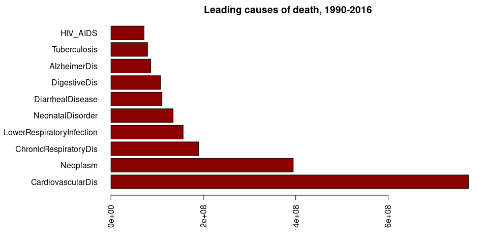

```r
par(mar=c(5,11,2,2))
barplot(leading_causes$freq, names.arg=rownames(leading_causes),
        horiz=T, las=2, col="darkred",
        main="Leading causes of death, 1990-2016")
```

# Basic correlations

Let’s now take a look at how these causes correlate with each other.

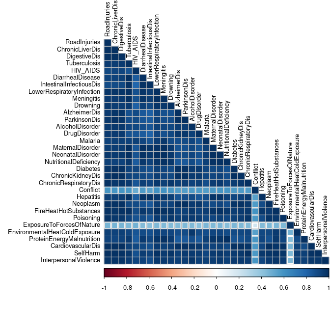

```r
corrplot(cor(D, use="pairwise"), method="square", type="lower", tl.cex=.8, tl.col="black")
```

All causes of death are positively correlated? That seems odd, but perhaps this is because of a population effect: countries with high populations will tend to have a high number of deaths, from *all* causes. Let’s see what happens if we look instead at *relative* levels of causality:

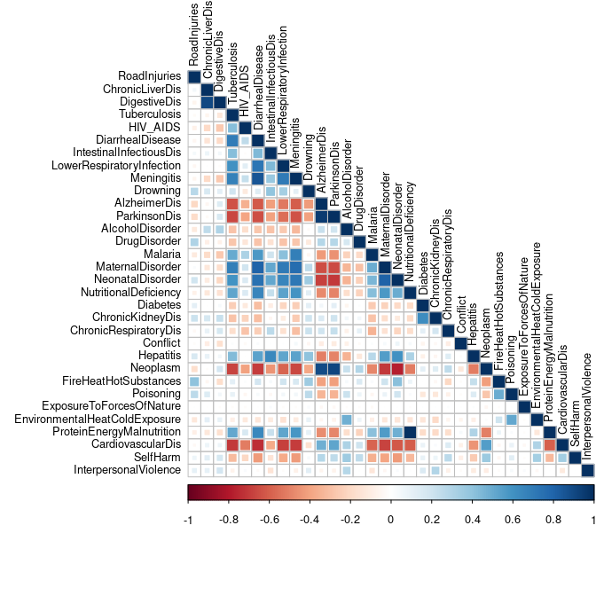

```r
D <- D / rowSums(D)
corrplot(cor(D, use="pairwise"), method="square", type="lower", tl.cex=.8, tl.col="black")
```

This is more interesting! Unsurprisingly, we see that some causes typically associated with old age - Alzheimer’s/Parkinson’s disease, cardiovascular disease, neoplasm (tumors) - are negatively correlated with causes typically associated with relatively less developed countries, such as communicable diseases and malnutrition.

# Principal Component Analysis

## Proportion of variance explained

Let’s see now what a simple PCA tells us:

```r
mort_PCA <- PCA(D, graph=F)
round(as.vector(mort_PCA$eig[,2]),2)[1:12]
```

```
##  [1] 31.86  9.77  7.65  6.49  5.47  4.01  3.58  3.41  3.15  3.05  2.72  2.39
```

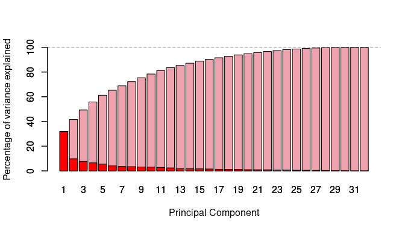

```r
barplot(mort_PCA$eig[,3], col="lightpink2", xlab="Principal Component",
        ylab="Percentage of variance explained",
        names.arg=1:dim(mort_PCA$eig)[1])
barplot(mort_PCA$eig[,2], add=T, col="red", names.arg=1:dim(mort_PCA$eig)[1])
abline(h=100, lty=2)
```

The first principal component explains a decent chunk of the variance (~32%), but the following ones much less.

## PCA plots

Let’s see how the variables plot against the two most important components (we will split this visualization between four graphs to avoid overcrowding):

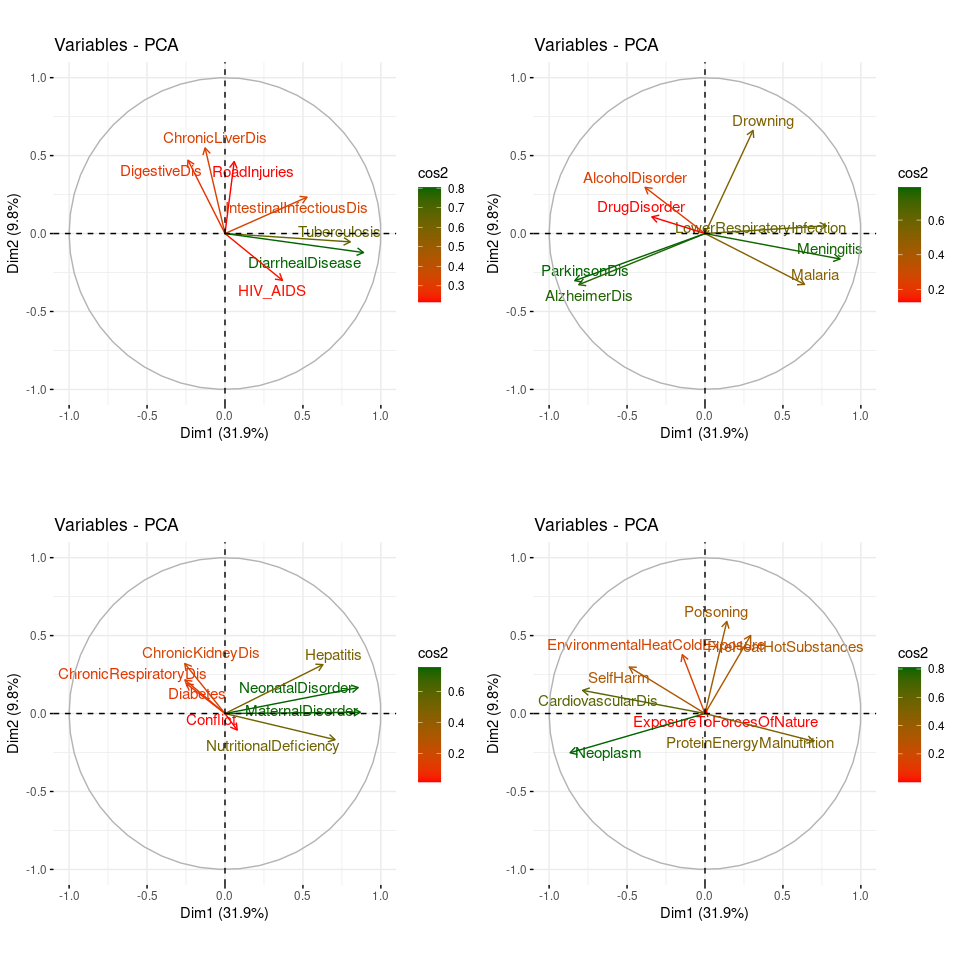

```r
circle_viz <- function(n) {
  N <- as.integer(dim(mort_PCA$eig)[1] / n)
  lapply(0:(n-1), function(i) {
    of_interest <- (1:N) + N*i
    fviz_pca_var(mort_PCA, col.var="cos2", repel=T, gradient.cols=c("red","darkgreen"),
                 select.var=list(name=causes[of_interest]))
  })
}
plots <- circle_viz(4)
grid.arrange(grobs=plots, nrow=2, ncol=2)
```

We notice that causes that were strongly negatively (and positively) correlated are well projected on the axis of the first principal component, in the opposite (and respectively same) direction. This first component is probably related to the level of economic development.

Looking at the second principal component, although the variables’ projections are too weak to draw strong conclusions, it looks like this dimension has something to do with individuals’ propensity for risk-taking and unhealthy habits: accidental or lifestyle-related causes of death seem to score relatively high on this axis, while old-age related causes (except for cardiovascular disease!) have negative values. This chimes with our intuition that although economic factors might be the biggest driver of differences, individual attitudes and habits are also significant.

We will not extend our PCA to projecting observations, as the sheer number of observations would force any readable graph of observations’ projections (nevermind biplots!) to include only a tiny fraction of the data. When it comes to observations, we are much likelier to find insights or trends using clustering methods.

# Clustering

## Variables

### Number of clusters to use

How many clusters should we use?

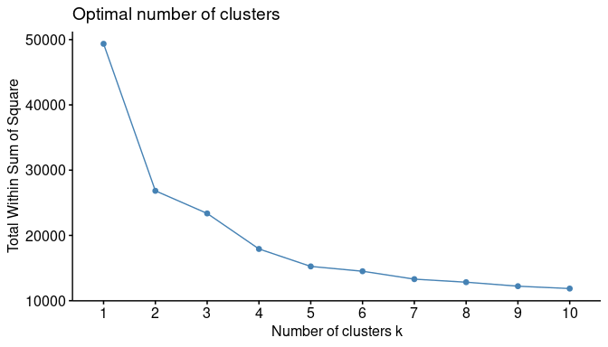

```r
D_scaled_vars <- (D - rowMeans(D)) / apply(D, 1, sd)
fviz_nbclust(D_scaled_vars, kmeans, method="wss")
```

It does not look like having more than 5 clusters is worth it.

### Dendrograms

Using hierarchical clustering, let’s look at the categories we get using various aggregation methods:

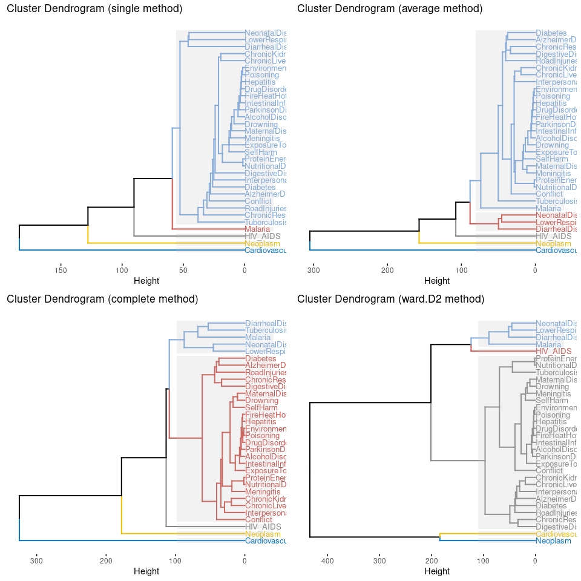

```r
dendrogram <- function(methods, k, dist_) {
  lapply(methods, function(method) {
    clusters <- hclust(d=dist_, method=method)
    fviz_dend(clusters, k=k, cex=.7, horiz=T, k_colors="jco", rect=T, rect_borders="jco",
              rect_fill=T, main=paste0("Cluster Dendrogram (", method, " method)"))
  })
}
var_dist <- dist(t(D_scaled_vars), method="euclidean")
methods <- c("single", "average", "complete", "ward.D2")
plots <- dendrogram(methods, 5, var_dist)
grid.arrange(grobs=plots, nrow=2, ncol=2)
```

Whichever method we use, cardiovascular disease, neoplasms and HIV/AIDS each have their own category, while almost everything else gets bunched into the same category.

### K-means

Let’s see if we get anything more interesting using the K-means algorithm:

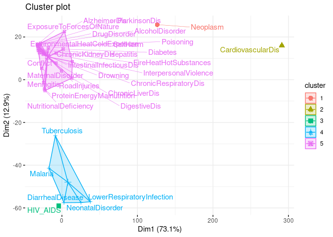

```r
var_groups <- kmeans(t(D_scaled_vars), 5, nstart=100)
fviz_cluster(var_groups, data=t(D_scaled_vars), star.plot=T,
             repel=T, ggtheme=theme_minimal())
```

…Not really! It doesn’t look like clustering causes of death will yield many insights. We might have better luck clustering country-year pairs on the basis of relative causes of mortality.

## Observations

### Number of clusters to use

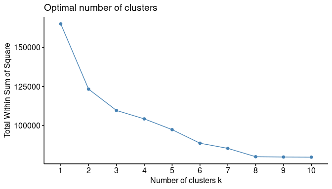

```r
D_scaled_obs <- t((t(D) - colMeans(D)) / apply(D, 2, sd))
fviz_nbclust(D_scaled_obs, kmeans, method="wss")
```

It looks like either 6 or 8 would be a reasonable choice for a number of clusters. However, having 6 clusters rather than 8 should make the results more understandable.

### K-means - stardard cluster visualization

```r
obs_groups <- kmeans(D_scaled_obs, 6, nstart=100)
```

For visualization, we will pick a sample of observations

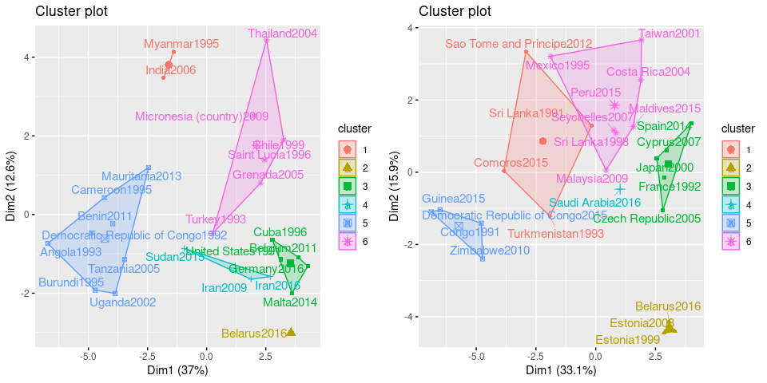

```r
cluster_sample <- function(n, size) {
  lapply(1:n, function(i) {
    obs_sample <- sample(1:dim(D_scaled_obs)[1], size, replace=F)
    obs_sampled <- obs_groups
    obs_sampled$cluster <- obs_groups$cluster[obs_sample]
    fviz_cluster(obs_sampled, data=D_scaled_obs[obs_sample,], repel=T)
  })
}
plots <- cluster_sample(2, 25)
grid.arrange(grobs=plots, nrow=1, ncol=2)
```

Some clusters stand out in their intuitive coherence: group #5 seems to include only African countries; group #6 seems to bunch together mostly middle-income tropical countries.

### K-means - World map

Perhaps these clusters will make more sense if we visualize them using a color-coded world map and fixed years.

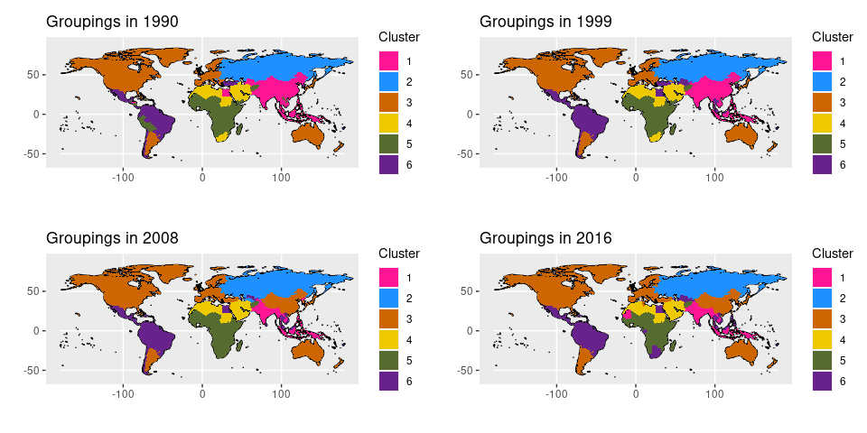

```r
df <- data.frame(Cluster=as.factor(obs_groups$cluster))
# We re-extract the keys rather pulling deaths[,1:2], to avoid index errors creeping in:
keys <- t(sapply(rownames(df), function(str) {
  n <- nchar(str)
  c(Entity=substr(str, 1, n-4),
    Year=substr(str, n-3, n))
}))
df <- cbind(df, keys)

# Adapted from https://stackoverflow.com/questions/30706124/plotting-the-
# world-map-in-r#30707148 - with slight adjustments for compatibility of mapping...
WorldData <- map_data('world') %>%
  filter(region != "Antarctica") %>%
  mutate(region = case_when(
    region == "USA" ~ "United States",
    region == "Greenland" ~ "Denmark",
    region == "Democratic Republic of the Congo" ~ "Democratic Republic of Congo",
    region == "Republic of Congo" ~ "Congo",
    TRUE ~ region
  ))

world_map_viz <- function(years) {
  lapply(years, function(year) {
    ggplot() +
      geom_map(data = WorldData, map = WorldData,
               aes(x = long, y = lat, group = group, map_id=region),
               fill = "white", colour = "black", size=0.5) +
      geom_map(data = df[which(df$Year==year),], map=WorldData,
               aes(fill=Cluster, map_id=Entity), size=0.5) +
      coord_map("rectangular", lat0=0, xlim=c(-180,180), ylim=c(-60, 90)) +
      scale_fill_manual(values=c("deeppink","dodgerblue1","darkorange3","gold2",
                                 "darkolivegreen","darkorchid4")) +
      labs(title = paste0("Groupings in ", year), x="", y="")
  })
}
plots <- world_map_viz(c(1990, 1999, 2008, 2016))
grid.arrange(grobs=plots, nrow=2, ncol=2)
```

The clusters seem to make sense, in terms of geography and general standards of living:

- We have a collection of South/South-East Asian countries in group 1;
- The former Soviet Union in group 2;
- Mostly developed nations in group 3;
- North Africa and the Middle East in group 4;
- Sub-Saharan Africa in group 5;
- Most of Latin America, with a smattering of mostly warm countries elsewhere in group 6;

That’s all well, but what do people in each of these different clusters actually tend to die from?

```r
apply(obs_groups$centers, 1, function(x) names(sort(x, decreasing=T))[1:5])
```

```
##      1                           2
## [1,] "IntestinalInfectiousDis"   "EnvironmentalHeatColdExposure"
## [2,] "Hepatitis"                 "Poisoning"
## [3,] "ChronicRespiratoryDis"     "AlcoholDisorder"
## [4,] "Drowning"                  "CardiovascularDis"
## [5,] "LowerRespiratoryInfection" "SelfHarm"
##      3                   4                       5
## [1,] "Neoplasm"          "RoadInjuries"          "Meningitis"
## [2,] "ParkinsonDis"      "FireHeatHotSubstances" "DiarrhealDisease"
## [3,] "AlzheimerDis"      "DrugDisorder"          "Tuberculosis"
## [4,] "CardiovascularDis" "Poisoning"             "Malaria"
## [5,] "SelfHarm"          "Conflict"              "MaternalDisorder"
##      6
## [1,] "ChronicKidneyDis"
## [2,] "Diabetes"
## [3,] "InterpersonalViolence"
## [4,] "DigestiveDis"
## [5,] "ChronicLiverDis"
```

It turns out that the data seems to support stereotypes about Russia (and former Soviet satellites)..! However, it would be quite incredible if environmental exposure to heat or cold was the biggest cause of death there. These results therefore carry a useful reminder of what *exactly* we are looking at: these causes are not necessarily the top causes of death in the clusters to which they are associated, but rather the causes whose proportions of deaths are highest *relative to the average proportion of deaths these causes are responsible for throughout the dataset.* If we instead look at the absolute numbers, the top causes of death in Russia differ markedly from our previous results:

```r
deaths %>%
  filter(Entity == "Russia" & Year == 2016) %>%
  select(-Entity, -Year) %>%
  sort(decreasing=T) %>%
  t %>% head %>% round
```

```
##                   Russia2016
## CardiovascularDis     997817
## Neoplasm              293426
## DigestiveDis           96666
## AlzheimerDis           83130
## ChronicLiverDis        52178
## SelfHarm               44501
```

# Relationships With Other Factors

Let’s now expand our analysis to see what factors might play a role in these differences. We will bring in the following datasets, all from OurWorldInData.org:

- [Wealth (GNI per capita)](https://ourworldindata.org/human-development-index#standard-of-living)
- Social:
  - [Government spending, as a share of GDP](https://ourworldindata.org/grapher/historical-gov-spending-gdp)
  - [Social spending categories, as shares of GDP](https://ourworldindata.org/grapher/social-expenditure-as-percentage-of-gdp)
  - [Trust (share of people agreeing with the statement “most people can be trusted”)](https://ourworldindata.org/grapher/self-reported-trust-attitudes)
  - [Inequality (Gini coefficient, before and net of redistributive policies)](https://ourworldindata.org/grapher/inequality-before-and-after-taxes-and-transfers-thewissen-et-al-data)
- Corruption:
  - [Bribery rates (share of people reporting having had to pay a bribe in the past year)](https://ourworldindata.org/grapher/bribery-rates)
  - [Corruption Perception Index (Transparency International)](https://ourworldindata.org/grapher/ti-corruption-perception-index)
- [Human Rights](https://ourworldindata.org/grapher/human-rights-scores)
- Pollution:
  - [Access to clean fuels/technologies for cooking (inverse proxy for indoor air pollution)](https://ourworldindata.org/indoor-air-pollution#only-60-of-the-world-has-access-to-clean-cooking-fuels)
  - [Mean annual exposure to PM2.5 air pollution (micrograms per cubic meter)](https://ourworldindata.org/outdoor-air-pollution#concentrations-of-air-pollution)
- Sanition:
  - [Share of population practicing open defecation](https://ourworldindata.org/sanitation#open-defecation)
  - [Share of population with access to improved sanitation facilities](https://ourworldindata.org/sanitation#access-to-improved-sanitation)
- Water:
  - [Share of population with access to an improved water source water](https://ourworldindata.org/water-access#what-share-of-people-have-access-to-an-improved-water-source)
  - [Share of population using safely managed drinking water](https://ourworldindata.org/water-access#access-to-safe-drinking-water)
- Nutrition:
  - [Per capita consumption of different cereal types](https://ourworldindata.org/grapher/per-capita-consumption-of-cereals-by-commodity-type-daily-kilocalories)
  - [Per capita supply of vegetables (kg/year)](https://ourworldindata.org/grapher/vegetable-consumption-per-capita)
  - [Per capita supply of fruits (kg/year)](https://ourworldindata.org/grapher/fruit-consumption-per-capita)
  - [Daily caloric supply from carbohydrates, protein and fat](https://ourworldindata.org/grapher/daily-caloric-supply-derived-from-carbohydrates-protein-and-fat)
  - [Dietary composition (kcal/day)](https://ourworldindata.org/grapher/dietary-compositions-by-commodity-group)

## Loading and taking a first look at the data

```r
datasets <- list(wealth="gross-national-income-per-capita.csv",
                 # Social
                 gov_spending="historical-gov-spending-gdp.csv",
                 social_spending="social-expenditure-as-percentage-of-gdp.csv",
                 trust="self-reported-trust-attitudes.csv",
                 inequality="inequality-before-and-after-taxes-and-transfers-Thewissen-et-al-data.csv",
                 # Corruption
                 bribery="bribery-rates.csv",
                 corr_perc_index="TI-corruption-perception-index.csv",
                 # Human Rights
                 human_rights="human-rights-scores.csv",
                 # Pollution
                 cooking_fuel="access-to-clean-fuels-and-technologies-for-cooking.csv",
                 PM25="PM25-air-pollution.csv",
                 # Sanitation
                 open_defecation="people-practicing-open-defecation-of-population.csv",
                 sanitation_access="share-of-population-with-improved-sanitation-facilities.csv",
                 # Water
                 improved_water="share-of-the-population-with-access-to-improved-drinking-water.csv",
                 safe_drinking_water="proportion-using-safely-managed-drinking-water.csv",
                 # Nutrition
                 cereals="per-capita-consumption-of-cereals-by-commodity-type-daily-kilocalories.csv",
                 vegetables="vegetable-consumption-per-capita.csv",
                 fruits="fruit-consumption-per-capita.csv",
                 calories="daily-caloric-supply-derived-from-carbohydrates-protein-and-fat.csv",
                 diet_composition="dietary-compositions-by-commodity-group.csv")

for(i in 1:length(datasets)) {
  this_data <- names(datasets)[i]
  eval(call("<-", as.name(this_data), read.csv(paste0(data_path, datasets[[i]]), header=T)))
  print(paste(" === ", this_data, " === "))
  cols <- colnames(eval(as.name(this_data)))
  if(!("Entity" %in% cols && "Year" %in% cols)) print("ERROR")
  else print(cols[-(1:3)])
  print("                                   ")
}
```

```
## [1] " ===  wealth  === "
## [1] "GNI.per.capita..PPP..constant.2011.international..."
## [1] "                                   "
## [1] " ===  gov_spending  === "
## [1] "Government.Expenditure..IMF.based.on.Mauro.et.al...2015.."
## [1] "                                   "
## [1] " ===  social_spending  === "
## [1] "Social.expenditure.on.family....of.GDP...OECD.Stats..2019.."
## [2] "Social.expenditure.on.health....of.GDP...OECD.Stats..2019.."
## [3] "Social.expenditure.on.housing....of.GDP...OECD.Stats..2019.."
## [4] "Incapacity.related.social.expenditures....of.GDP...OECD.Stats..2019.."
## [5] "Old.age.related.social.expenditures....of.GDP...OECD.Stats..2019.."
## [6] "Social.expenditure.on.other.social.policy.areas....of.GDP...OECD.Stats..2019.."
## [7] "Social.expenditure.on.survivors....of.GDP...OECD.Stats..2019.."
## [8] "Social.expenditure.on.unemployment....of.GDP...OECD.Stats..2019.."
```

[output cut: 69 more lines]

Let’s rename the columns of these datasets, to make them cleaner (plus a small transformation on the *calories* dataset).

```r
colnames(wealth)[4] <- "GNIperCapita"
colnames(gov_spending)[4] <- "PctGDPGovSpending"
cats <- c("Family", "Health", "Housing", "Incapacity", "OldAge", "Other",
          "Survivors", "Unemployment", "ActiveLaborMktPolicy")
colnames(social_spending)[4:12] <- paste0("SocialSp_", cats)
colnames(trust)[4] <- "TrustInOthers"
colnames(inequality)[4:5] <- c("GINI_net", "GINI_raw")
colnames(bribery)[4] <- "BriberyRate"
colnames(corr_perc_index)[4] <- "CorruptionPerceptionIndex"
colnames(human_rights)[4] <- "HumanRightsScore"
colnames(cooking_fuel)[4] <- "AccessToCleanCookingFuel"
colnames(PM25)[4] <- "PM25Exposure"
colnames(open_defecation)[4] <- "OpenDefecationPct"
colnames(sanitation_access)[4] <- "AccessImprovedSanitationPct"
colnames(improved_water)[4] <- "ImprovedWaterAccessPct"
colnames(safe_drinking_water)[4] <- "SafeDrinkingWaterAccessPct"
cats <- c("Wheat", "Rice", "Barley", "Maize", "Rye", "Oats", "Sorghum")
colnames(cereals)[4:10] <- paste0("Cereals_", cats)
colnames(vegetables)[4] <- "VegetablesFoodSupplyPerCapita"
colnames(fruits)[4] <- "FruitsFoodSupplyPerCapita"
cats <- c("CerealsGrains", "Pulses", "StarchyRoots", "Sugar", "OilFats", "Meat",
          "DairyEggs", "FruitVegetables", "Other", "AlcoholicBeverages")
colnames(diet_composition)[4:13] <- paste0("Diet_", cats)
colnames(calories)[4:7] <- paste0("Calories_", c("Fat", "Carbohydrates",
                                                 "AnimalProtein", "PlantProtein"))
# Transform calories into proportions and a total
Calories_Total <- rowSums(calories[, 4:7], na.rm=T)
calories[, 4:7] <- calories[, 4:7] / Calories_Total
calories <- cbind(calories, Calories_Total)
```

Let’s see if the other datasets have more or less the same number of observations as our *deaths* dataset, to see if we could merge everything in one big set.

```r
t(sapply(names(datasets), function(name) dim(eval(as.name(name)))))
```

```
##                      [,1] [,2]
## wealth               4624    4
## gov_spending         7091    4
## social_spending       284   12
## trust                 237    4
## inequality            180    5
## bribery               206    4
## corr_perc_index      1229    4
## human_rights        11717    4
## cooking_fuel         3995    4
## PM25                 2640    4
## open_defecation      4044    4
## sanitation_access    6211    4
## improved_water       6248    4
## safe_drinking_water  1511    4
## cereals             10393   10
## vegetables          11028    4
## fruits              11028    4
## calories             8981    8
## diet_composition     8154   13
```

The lengths differ widely, so doing an “inner join” using everything at the same time would probably leave very few observations in the resulting dataset. We’re going to have to deal with them one by one.

## Missing values

Do these datasets contain missing values?

```r
NA_content <- sapply(names(datasets), function(c_) mean(is.na(eval(as.name(c_)))))
(have_NAs <- NA_content[NA_content > 0])
```

```
##  social_spending       inequality          cereals diet_composition
##     0.0401995305     0.0100000000     0.0926873857     0.0004999906
```

Let’s take a further look at these datasets’ distributions of NA’s.

```r
further_checks <- list(social_spending, inequality, cereals, diet_composition)
na_dist <- t(sapply(further_checks, check_NA_dist))
rownames(na_dist) <- names(have_NAs)
na_dist
```

```
##                         rows       cols
## social_spending  0.172535211 0.75000000
## inequality       0.050000000 0.20000000
## cereals          0.660348311 0.50000000
## diet_composition 0.006499877 0.07692308
```

```r
for(i in 1:length(further_checks)) {
  print(paste("===", names(have_NAs)[i], "==="))
  print(apply(further_checks[[i]], 2, function(v) mean(is.na(v))))
  print("                   ")
}
```

```
## [1] "=== social_spending ==="
##                        Entity                          Code
##                   0.000000000                   0.000000000
##                          Year               SocialSp_Family
##                   0.000000000                   0.045774648
##               SocialSp_Health              SocialSp_Housing
##                   0.007042254                   0.080985915
##           SocialSp_Incapacity               SocialSp_OldAge
##                   0.045774648                   0.042253521
##                SocialSp_Other            SocialSp_Survivors
##                   0.042253521                   0.042253521
##         SocialSp_Unemployment SocialSp_ActiveLaborMktPolicy
##                   0.080985915                   0.095070423
## [1] "                   "
## [1] "=== inequality ==="
##   Entity     Code     Year GINI_net GINI_raw
##     0.00     0.00     0.00     0.00     0.05
## [1] "                   "
## [1] "=== cereals ==="
##          Entity            Code            Year   Cereals_Wheat    Cereals_Rice
##      0.00000000      0.00000000      0.00000000      0.00000000      0.00000000
##  Cereals_Barley   Cereals_Maize     Cereals_Rye    Cereals_Oats Cereals_Sorghum
##      0.06956605      0.01327817      0.21841624      0.07562783      0.54998557
## [1] "                   "
## [1] "=== diet_composition ==="
##                  Entity                    Code                    Year
##             0.000000000             0.000000000             0.000000000
##      Diet_CerealsGrains             Diet_Pulses       Diet_StarchyRoots
##             0.000000000             0.000000000             0.000000000
##              Diet_Sugar            Diet_OilFats               Diet_Meat
##             0.000000000             0.000000000             0.000000000
##          Diet_DairyEggs    Diet_FruitVegetables              Diet_Other
##             0.000000000             0.000000000             0.000000000
## Diet_AlcoholicBeverages
##             0.006499877
## [1] "                   "
```

- *social_spending* has missing values all over the place;
- *inequality* is only missing a few values in one column;
- *cereals* has complete data for wheat and rice, and significant amounts of NA’s for rye and sorghum. This one will require a bit of digging to see how random the distribution of these missing values is;
- *diet_composition* is only missing a few data points in one column - the one covering alcoholic beverages. Does this have anything to do with religion? Let’s find out!

Let us start with *social_spending*:

```r
rows_w_NAs <- apply(social_spending, 1, function(v) sum(is.na(v)))
table(rows_w_NAs[rows_w_NAs > 0])
```

```
##
##  1  2  3  4  6  7  8
## 32  3  1  1  1  2  9
```

Most lines with missing data are only missing one point. Surgically removing these data points should probably be OK. Let’s look at missing values for *inequality*:

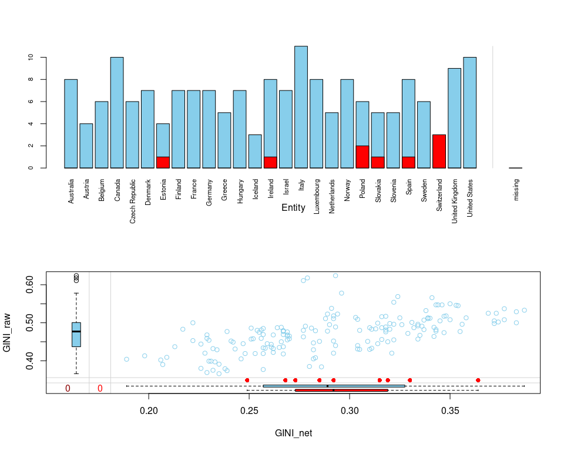

```r
par(mfrow=c(2,1))
histMiss(inequality, cex.axis=.7)
marginplot(inequality[,c("GINI_net", "GINI_raw")])
```

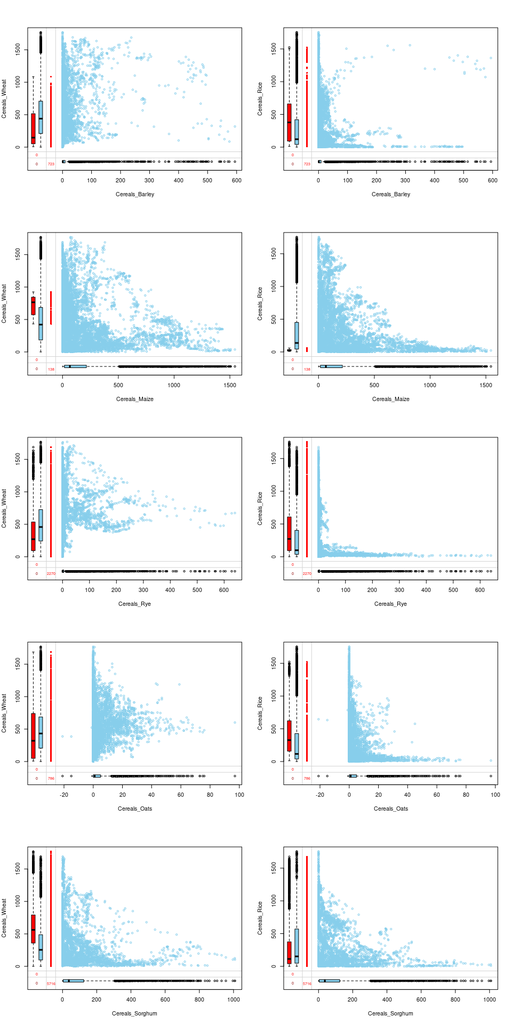

```r
check <- colnames(cereals)[apply(cereals, 2, function(v) sum(is.na(v)) > 0)]
par(mfrow=c(5,2))
for(i in 1:length(check)) {
  marginplot(cereals[,c(check[i], "Cereals_Wheat")])
  marginplot(cereals[,c(check[i], "Cereals_Rice")])
}
```

Most of the missing values seem to have distributions that differ markedly from the distributions of *Cereals_Wheat* and *Cereals_Rice*, for which we have complete data. This suggests that the missingness of values here contains information in and of itself. We will therefore create new columns indicating whether data is missing or not.

```r
for(i in 1:length(check)) {
  missing <- check[i]
  cereals <- cereals %>%
    mutate(missing_val=as.numeric(is.na(cereals[, missing])))
  colnames(cereals)[length(colnames(cereals))] <- paste0("Missing_", missing)
}
```

Finally, let’s look at *diet_composition*:

```r
diet_composition %>%
  filter(is.na(Diet_AlcoholicBeverages)) %>%
  select(Entity) %>%
  unique
```

```
##                 Entity
## 1 United Arab Emirates
```

We are missing data for this column for a single muslim-majority country. We can probably just ignore these observations when we’ll be computing correlations for the *Diet_AlcoholicBeverages* column.

## Correlations

To look at correlations, we will need our normalized *deaths* dataset. This is our previously created *D* object, can we safely merge the latter with the former?

```r
rbind(dim(deaths), dim(D))
```

```
##      [,1] [,2]
## [1,] 5157   34
## [2,] 5157   32
```

```r
test <- sample(1:dim(D)[1], 10, replace=F)
cbind(deaths[test, c("Entity", "Year")], D_names=rownames(D)[test], row.names=1:10)
```

```
##           Entity Year           D_names
## 1       Maldives 2007      Maldives2007
## 2   South Africa 2000  South Africa2000
## 3     Seychelles 2002    Seychelles2002
## 4       Zimbabwe 2004      Zimbabwe2004
## 5        Tunisia 1993       Tunisia1993
## 6          Spain 1999         Spain1999
## 7        Nigeria 2006       Nigeria2006
## 8  Guinea-Bissau 1992 Guinea-Bissau1992
## 9           Togo 2007          Togo2007
## 10        Malawi 1996        Malawi1996
```

All good!

```r
norm_deaths <- cbind(deaths[, 1:2], D)
correlate_dataset <- function(comparison) {
  compar_df <- comparison %>%
    as.name %>% eval
  cols <- colnames(compar_df)[-(1:3)]
  corr_mat <- sapply(cols, function(this_col) {
    temp_df <- compar_df[, c("Entity", "Year", this_col)] %>%
      na.omit %>%
      inner_join(norm_deaths, by=c("Entity", "Year"))
    cor_vec <- t(head(cor(temp_df[, -(1:2)]), 1))[-1]
  })
  return(corr_mat)
}
correlations <- matrix(nrow=32, ncol=0)
for(n in names(datasets)) correlations <- cbind(correlations, correlate_dataset(n))
rownames(correlations) <- colnames(deaths)[-(1:2)]
```

### Visualization

Now let’s visualize the correlations!

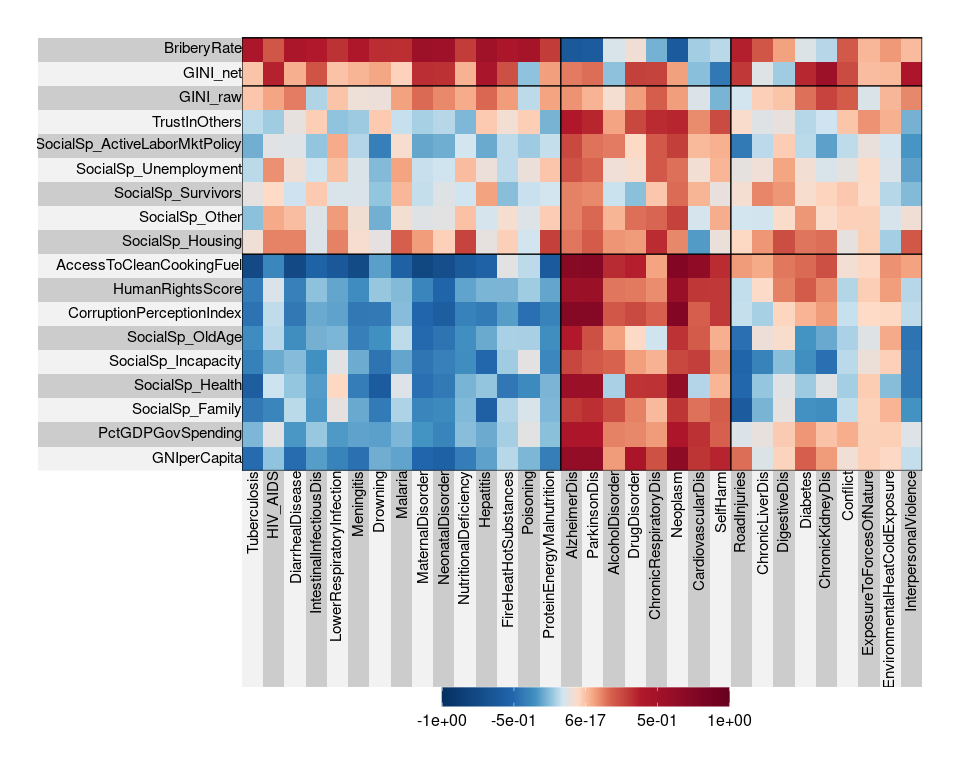

```r
corr_viz <- function(rng) {
  superheat(t(correlations)[rng,], heat.pal=brewer.pal(10, "RdBu")[10:1],
            bottom.label.text.size=4, bottom.label.text.angle = 90,
            left.label="variable", bottom.label="variable",
            left.label.text.size=4, n.clusters.rows=3, n.clusters.cols=3,
            legend.height=.1, heat.lim=c(-1,1), bottom.label.text.alignment="right",
            bottom.label.size = .5, left.label.text.alignment="right",
            left.label.size=.3)
}
corr_viz(1:18)
```

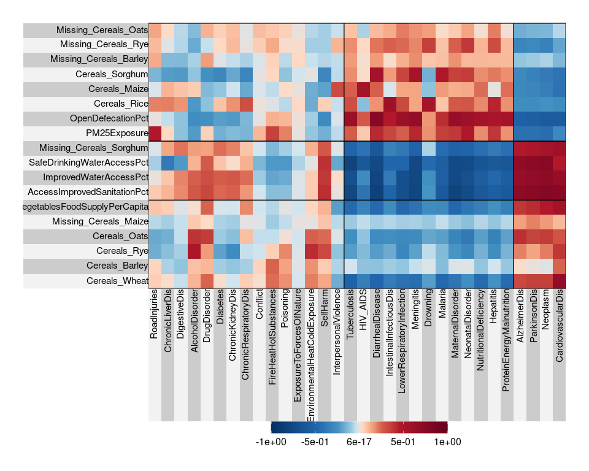

```r
corr_viz(19:36)
```

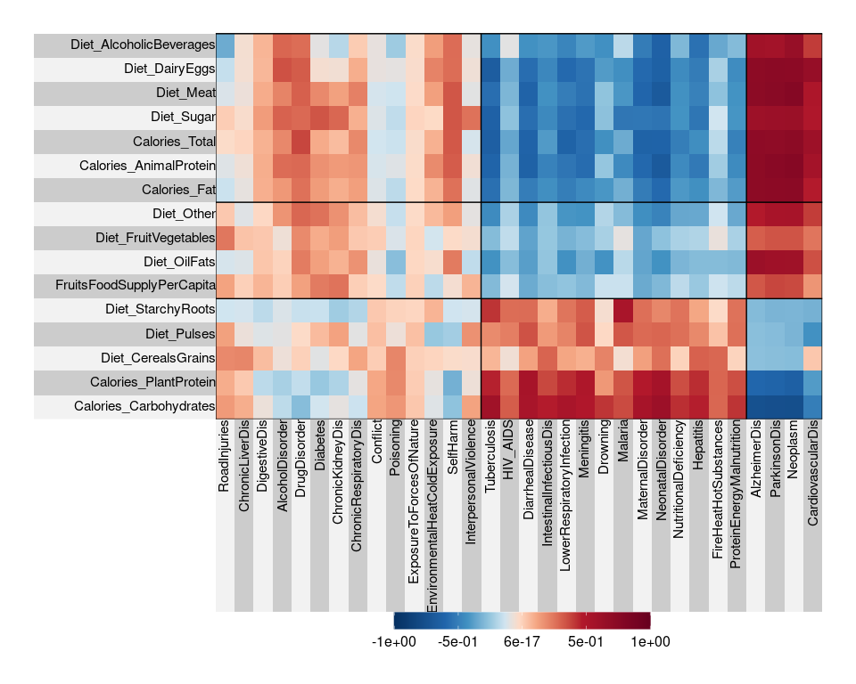

```r
corr_viz(37:52)
```

There’s quite a lot to unpack in these graphs! Overall, however, they seem to confirm our intuition.